# R Notebook

# MVP

1. Load the `housing_prices.csv` data set and undertake an initial exploration of the data. You will find details on the data set on the relevant [Kaggle page](https://www.kaggle.com/camnugent/california-housing-prices)

**Ans**

Call libraries

```r
library(janitor)
```

```r
housing <- read_csv(here("data/housing_prices.csv"))
glimpse(housing)
```

```
Rows: 19,675
Columns: 10
$ longitude          <dbl> -122.23, -122.22, -122.24, -122.25, -122.25, -122.25, -122.25, -122.25, -122.26, -122.25, -122.26, -122.26,~
$ latitude           <dbl> 37.88, 37.86, 37.85, 37.85, 37.85, 37.85, 37.84, 37.84, 37.84, 37.84, 37.85, 37.85, 37.85, 37.84, 37.85, 37~
$ housing_median_age <dbl> 41, 21, 52, 52, 52, 52, 52, 52, 42, 52, 52, 52, 52, 52, 52, 50, 52, 52, 50, 52, 40, 42, 52, 52, 52, 41, 49,~
$ total_rooms        <dbl> 880, 7099, 1467, 1274, 1627, 919, 2535, 3104, 2555, 3549, 2202, 3503, 2491, 696, 2643, 1120, 1966, 1228, 22~
$ total_bedrooms     <dbl> 129, 1106, 190, 235, 280, 213, 489, 687, 665, 707, 434, 752, 474, 191, 626, 283, 347, 293, 455, 298, 184, 3~
$ population         <dbl> 322, 2401, 496, 558, 565, 413, 1094, 1157, 1206, 1551, 910, 1504, 1098, 345, 1212, 697, 793, 648, 990, 690,~
$ households         <dbl> 126, 1138, 177, 219, 259, 193, 514, 647, 595, 714, 402, 734, 468, 174, 620, 264, 331, 303, 419, 275, 166, 3~
$ median_income      <dbl> 8.3252, 8.3014, 7.2574, 5.6431, 3.8462, 4.0368, 3.6591, 3.1200, 2.0804, 3.6912, 3.2031, 3.2705, 3.0750, 2.6~
$ median_house_value <dbl> 452600, 358500, 352100, 341300, 342200, 269700, 299200, 241400, 226700, 261100, 281500, 241800, 213500, 191~
$ ocean_proximity    <chr> "NEAR BAY", "NEAR BAY", "NEAR BAY", "NEAR BAY", "NEAR BAY", "NEAR BAY", "NEAR BAY", "NEAR BAY", "NEAR BAY",~
```

Check data for NA values

```r
housing  %>%
  summarise(across(.cols = everything(),
                   .fns = ~sum(is.na(.x))))
```

| longitude | latitude | housing_median_age | total_rooms | total_bedrooms | population | households | median_income | median_house_value | ocean_proximity |
| --- | --- | --- | --- | --- | --- | --- | --- | --- | --- |
| 0 | 0 | 0 | 0 | 200 | 0 | 0 | 0 | 0 | 0 |

```r
NA
```

2. We expect the `total_rooms` of houses to be strongly correlated with `total_bedrooms`. Use `ggpairs()` to investigate correlations between these two variables.

**Ans**

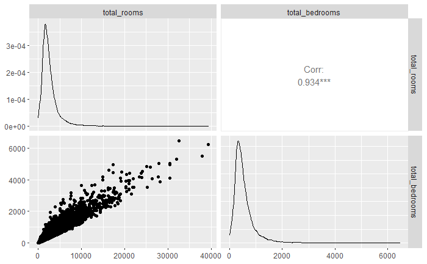

```r
ggpairs(select(housing, total_rooms, total_bedrooms))
```

Variables have a strong positive correlation (r = 0.934)

3. So, we do find significant correlations. Let’s drop `total_bedrooms` from the dataset, and use only `total_rooms` going forward.

**Ans**

```r
housing <- housing  %>%
  select(-total_bedrooms)
```

4. We are interested in developing a regression model for the `median_house_value` of a house in terms of the possible predictor variables in the dataset.
1. Use `ggpairs()` to investigate correlations between `median_house_value` and the predictors (this may take a while to run, don’t worry, make coffee or something).
2. Perform further `ggplot` visualisations of any significant correlations you find.

**Ans**

[output not shown]

[output cut: 34 more lines]

[output not shown]

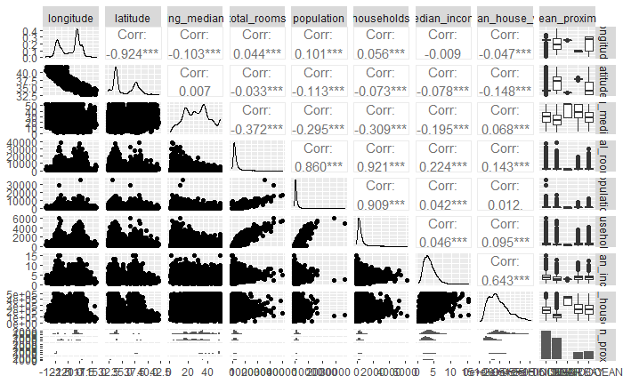

```r
# ggpairs(housing, columns = 3:9)
ggpairs(housing, columns = 1:9)
```

5. Shortly we may try a regression model to fit the categorical predictor `ocean_proximity`. Investigate the level of `ocean_proximity` predictors. How many dummy variables do you expect to get from it?

**Ans**

```r
housing %>%
  distinct(ocean_proximity)
```

| ocean_proximity |
| --- |
| NEAR BAY |
| <1H OCEAN |
| INLAND |
| NEAR OCEAN |
| ISLAND |

We expect to get 4 (= 5-1) dummy variables

6. Start with simple linear regression. Regress `median_house_value` on `median_income` and check the regression diagnostics.

**Ans**

Regression:

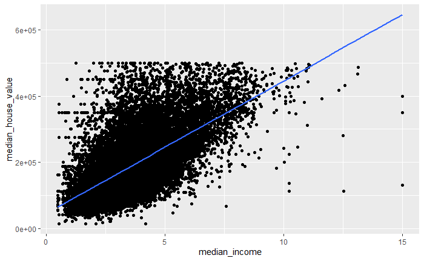

```r
housing %>%
  ggplot(aes(x = median_income, y = median_house_value)) +
  geom_point() +
  geom_smooth(method = "lm", se = FALSE)
```

Diagnostics

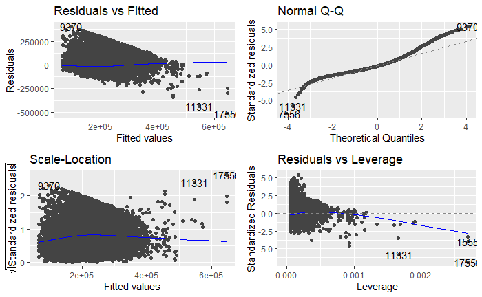

```r
model <- lm(median_house_value ~ median_income, data = housing)

autoplot(model)
```

```r
summary(model)
```

```
Call:
lm(formula = median_house_value ~ median_income, data = housing)

Residuals:
    Min      1Q  Median      3Q     Max
-513966  -51564  -13979   36549  403935

Coefficients:
              Estimate Std. Error t value Pr(>|t|)
(Intercept)    45457.0     1359.0   33.45   <2e-16 ***
median_income  39987.0      339.9  117.64   <2e-16 ***
---
Signif. codes:  0 ‘***’ 0.001 ‘**’ 0.01 ‘*’ 0.05 ‘.’ 0.1 ‘ ’ 1

Residual standard error: 74870 on 19673 degrees of freedom
Multiple R-squared:  0.4129,    Adjusted R-squared:  0.4129
F-statistic: 1.384e+04 on 1 and 19673 DF,  p-value: < 2.2e-16
```

The model is not adequate - the residuals are not following a normal distribution.

7. Add another predictor of your choice. Check your assumptions, diagnostics, and interpret the model.

**Ans** Add housing median age into the model:

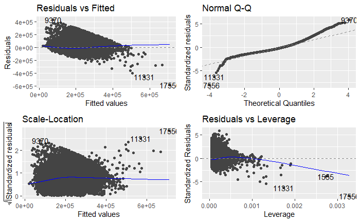

```r
model2 <- lm(median_house_value ~ median_income + housing_median_age, data = housing)

autoplot(model2)
```

```r
summary(model2)
```

```
Call:
lm(formula = median_house_value ~ median_income + housing_median_age,
    data = housing)

Residuals:
    Min      1Q  Median      3Q     Max
-578542  -49267  -12466   35993  424519

Coefficients:
                   Estimate Std. Error t value Pr(>|t|)
(Intercept)        -7997.53    1944.06  -4.114 3.91e-05 ***
median_income      42420.02     334.93 126.655  < 2e-16 ***
housing_median_age  1567.98      42.04  37.294  < 2e-16 ***
---
Signif. codes:  0 ‘***’ 0.001 ‘**’ 0.01 ‘*’ 0.05 ‘.’ 0.1 ‘ ’ 1

Residual standard error: 72360 on 19672 degrees of freedom
Multiple R-squared:  0.4517,    Adjusted R-squared:  0.4517
F-statistic:  8104 on 2 and 19672 DF,  p-value: < 2.2e-16
```

# Extension

8. Try adding an interaction between `log(medium_income)` and your chosen categorical predictor. Do you think this interaction term is statistically justified?

**Ans** Chosen categorical predictor: ocean_proximity

[output not shown]

[output cut: 990 more lines]

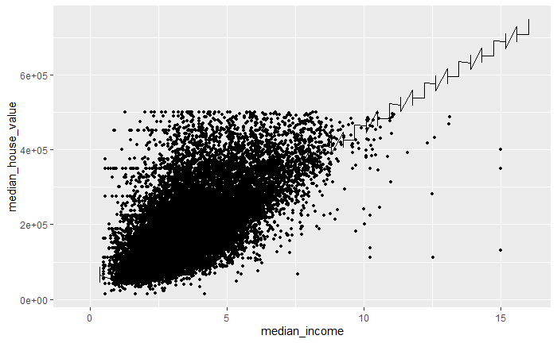

```r
model3 <- lm(median_house_value ~ median_income + housing_median_age +
             # log10(median_income)*ocean_proximity_inland +
             # log10(median_income)*ocean_proximity_island +
             # log10(median_income)*ocean_proximity_near_bay +
             log10(median_income)*ocean_proximity_near_ocean,
             data = housing_dummy)
plotModel(model3)
```

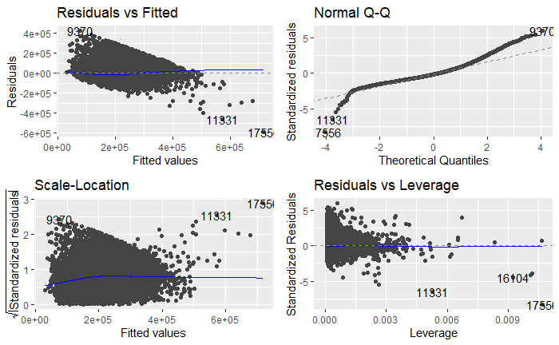

```r
autoplot(model3)
```

```r
summary(model3)
```

```
Call:
lm(formula = median_house_value ~ median_income + housing_median_age +
    log10(median_income) * ocean_proximity_near_ocean, data = housing_dummy)

Residuals:
    Min      1Q  Median      3Q     Max
-586557  -47482  -11958   34871  423920

Coefficients:
                                                 Estimate Std. Error t value Pr(>|t|)
(Intercept)                                      -7486.36    2169.11  -3.451 0.000559 ***
median_income                                    45272.51    1110.09  40.783  < 2e-16 ***
housing_median_age                                1536.70      41.36  37.155  < 2e-16 ***
log10(median_income)                            -28617.98    9141.10  -3.131 0.001747 **
ocean_proximity_near_ocean                       20301.28    4680.86   4.337 1.45e-05 ***
log10(median_income):ocean_proximity_near_ocean  36555.35    8386.15   4.359 1.31e-05 ***
---
Signif. codes:  0 ‘***’ 0.001 ‘**’ 0.01 ‘*’ 0.05 ‘.’ 0.1 ‘ ’ 1

Residual standard error: 71130 on 19669 degrees of freedom
Multiple R-squared:  0.4702,    Adjusted R-squared:   0.47
F-statistic:  3491 on 5 and 19669 DF,  p-value: < 2.2e-16
```

9. Find and plot an appropriate visualisation to show the effect of this interaction

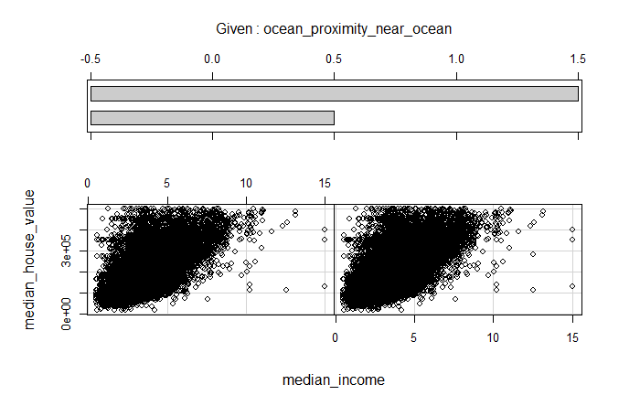

```r
coplot(median_house_value ~ median_income | ocean_proximity_near_ocean,
       data = housing_dummy)
```